# Regression Models Course Project

Mohit Shukla

Sunday, May 24, 2015

##### Summary

This report includes an analysis of mtcars data set which is a collection of cars, main interest of exploration is to understand the relationship between a set of variables and miles per gallon (MPG) (outcome). Main focus of the analysis is the two following aspects:

- “Is an automatic or manual transmission better for MPG”
- “Quantify the MPG difference between automatic and manual transmissions”

This analysis may follow many models depending upon the number of covariates being included. Hence A model comparison test is performed to test the relative reliablility of different models. A number of exploratory analysis tasks have been performed to check the validity of models.

**Analysis of mpg based on factor variable am**

```r
data(mtcars)
data <-  mtcars[,c("mpg","am")]
data[,"am"] <-  as.factor(data[,"am"])
attach(data)
summary(mpg[am == 1])
```

```
##    Min. 1st Qu.  Median    Mean 3rd Qu.    Max.
##   15.00   21.00   22.80   24.39   30.40   33.90
```

```r
summary(mpg[am == 0])
```

```
##    Min. 1st Qu.  Median    Mean 3rd Qu.    Max.
##   10.40   14.95   17.30   17.15   19.20   24.40
```

```r
fit <- lm(mpg~am)
summary(fit)$coef
```

```
##              Estimate Std. Error   t value     Pr(>|t|)
## (Intercept) 17.147368   1.124603 15.247492 1.133983e-15
## am1          7.244939   1.764422  4.106127 2.850207e-04
```

Above analysis shows dominance of am==1 i.e. Manual transmission. Since the data were coded as 0/1, the coefficient is directly interpreted as the manual (1) - auto (0) difference. In other words, manual on average were 7.245 points greater than auto, a significant difference.

**Analysis of mpg based on all the covariates**

```r
data(mtcars)
model <- lm(mpg~., data=mtcars)
(summary(model)$coef)["am",]
```

```
##   Estimate Std. Error    t value   Pr(>|t|)
##  2.5202269  2.0566506  1.2254035  0.2339897
```

The above model shows that manual transmission on average is 2.5202269 points better than the auto transmission. Now this is serious **conflict** between sigle covariate model and all covariate model. To decide between these two and all the other available models a model selection test is performed below.

**Model Selection**

```r
data(mtcars)
fit10 <- lm(mpg~ am, data=mtcars)
fit9 <- update(fit10, mpg~  cyl + am, data=mtcars)
fit8 <- update(fit10, mpg~  cyl + disp + am, data=mtcars)
fit7 <- update(fit10, mpg~  cyl + disp + hp + am, data=mtcars)
fit6 <- update(fit10, mpg~  cyl + disp + hp + drat + am, data=mtcars)
fit5 <- update(fit10, mpg~  cyl + disp + hp + drat + wt + am, data=mtcars)
fit4 <- update(fit10, mpg~  cyl + disp + hp + drat + wt + qsec + am , data=mtcars)
fit3 <- update(fit10, mpg~  cyl + disp + hp + drat + wt + qsec + vs+ am , data=mtcars)
fit2 <- update(fit10, mpg~  cyl + disp + hp + drat + wt + qsec + vs+ am + gear, data=mtcars)
fit1 <- update(fit10, mpg~ cyl + disp + hp + drat + wt + qsec + vs+ am + gear + carb, data=mtcars)
anova(fit10,fit9,fit8,fit7,fit6,fit5,fit4,fit3,fit2,fit1)
```

```
## Analysis of Variance Table
##
## Model  1: mpg ~ am
## Model  2: mpg ~ cyl + am
## Model  3: mpg ~ cyl + disp + am
## Model  4: mpg ~ cyl + disp + hp + am
## Model  5: mpg ~ cyl + disp + hp + drat + am
## Model  6: mpg ~ cyl + disp + hp + drat + wt + am
## Model  7: mpg ~ cyl + disp + hp + drat + wt + qsec + am
## Model  8: mpg ~ cyl + disp + hp + drat + wt + qsec + vs + am
## Model  9: mpg ~ cyl + disp + hp + drat + wt + qsec + vs + am + gear
## Model 10: mpg ~ cyl + disp + hp + drat + wt + qsec + vs + am + gear + carb
##    Res.Df    RSS Df Sum of Sq       F    Pr(>F)
## 1      30 720.90
## 2      29 271.36  1    449.53 64.0039 8.231e-08 ***
## 3      28 252.08  1     19.28  2.7452   0.11241
## 4      27 216.37  1     35.71  5.0849   0.03493 *
## 5      26 214.50  1      1.87  0.2663   0.61121
## 6      25 162.43  1     52.06  7.4127   0.01275 *
## 7      24 149.09  1     13.34  1.8999   0.18260
## 8      23 148.87  1      0.22  0.0309   0.86214
## 9      22 147.90  1      0.97  0.1384   0.71365
## 10     21 147.49  1      0.41  0.0579   0.81218
## ---
## Signif. codes:  0 '***' 0.001 '**' 0.01 '*' 0.05 '.' 0.1 ' ' 1
```

```r
anova(fit10,fit1)
```

```
## Analysis of Variance Table
##
## Model 1: mpg ~ am
## Model 2: mpg ~ cyl + disp + hp + drat + wt + qsec + vs + am + gear + carb
##   Res.Df    RSS Df Sum of Sq      F    Pr(>F)
## 1     30 720.90
## 2     21 147.49  9     573.4 9.0711 1.779e-05 ***
## ---
## Signif. codes:  0 '***' 0.001 '**' 0.01 '*' 0.05 '.' 0.1 ' ' 1
```

**Result**

- coefficients for “am” are: 2.5202269, 2.0566506, 1.2254035, 0.2339897
- Manual Transmission (am==1) is 2.5202269 points better than Automatic Transmission i.e. (am==0)

**Appendix**

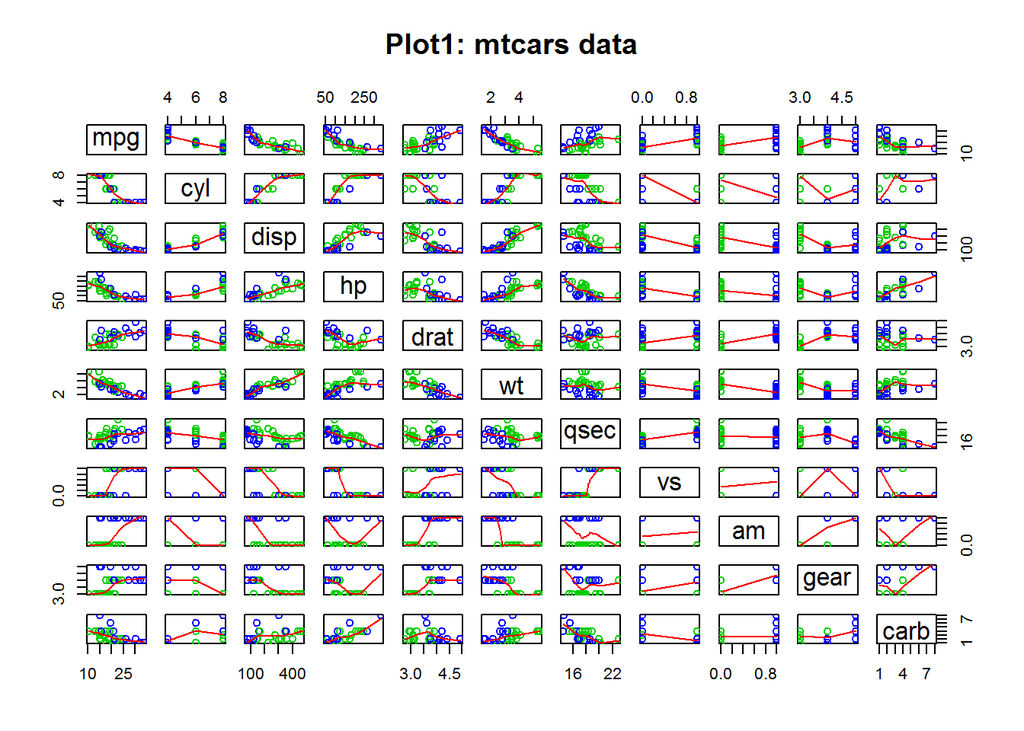

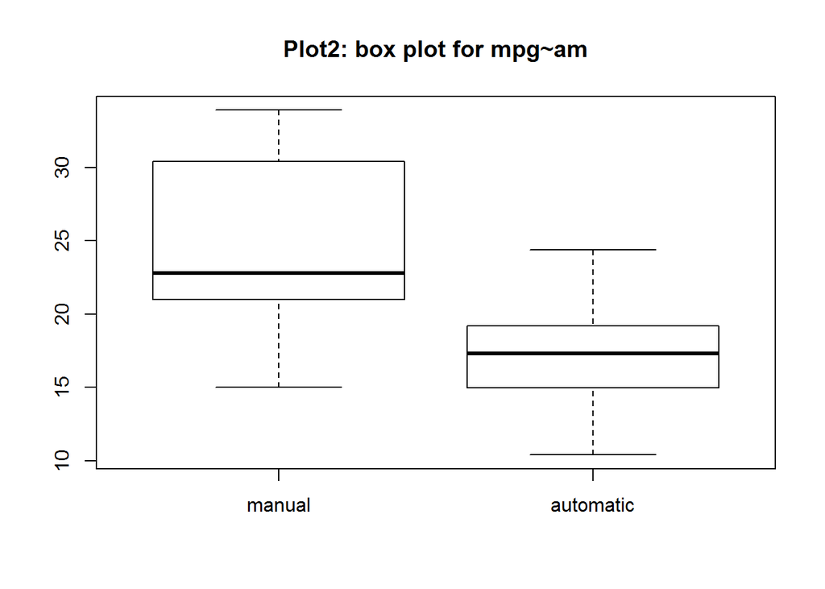

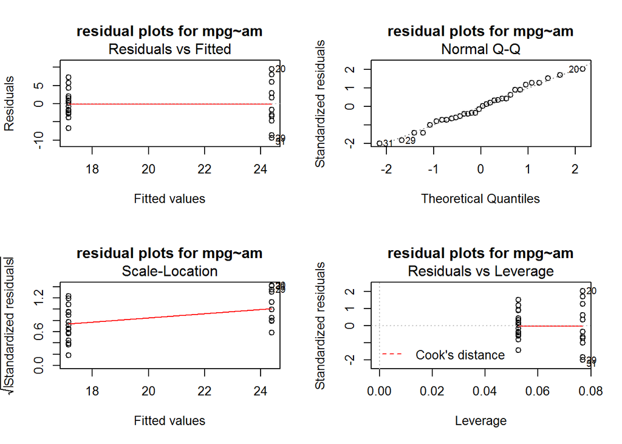

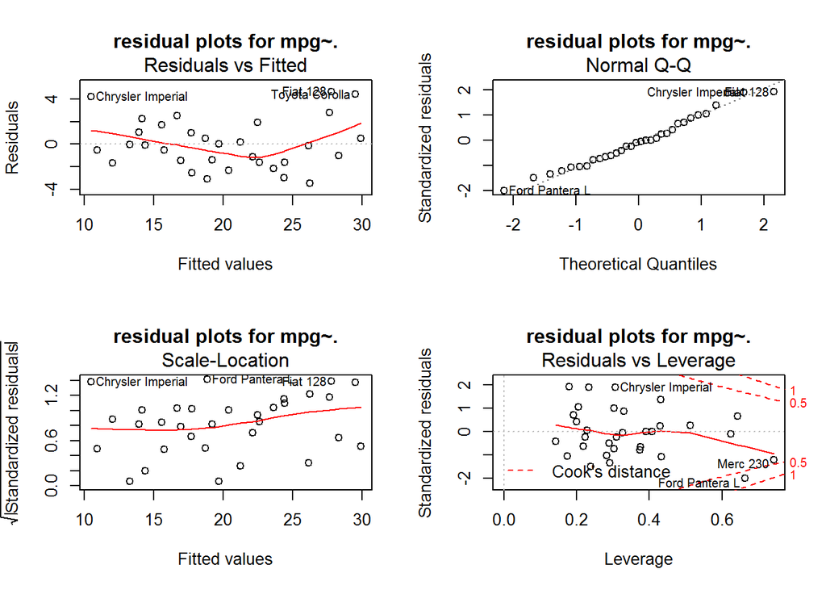